# Data Analysis and Visualization Report

## Introduction:

This is a project on Analysis and Visualization of WeRateDogs twitter archive. The analysis is focused on exploring the number of images on each tweets, retweet count and like count as well as the relationship between them

### Insight #1:

**Number of images on the tweet**

Analysis of the number of images on the tweets showed the highest number of images is four but most of the tweets contains just one image of a dog. Tweets with just one image takes are more than the ones with more than images as shown below;

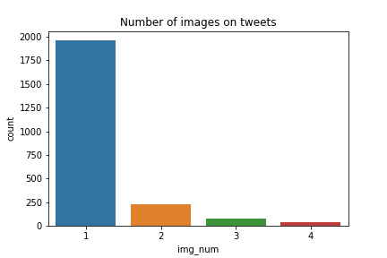

### Insight #2:

**Stages of the dogs**

In most of the tweets, the dog stages were not stated. The dog stages however stated in some tweets includes Doggo,Floofer,Pupper and Puppo. The fifth division in the plot below is used to indicate the dogs whose stages were not stated in the tweets

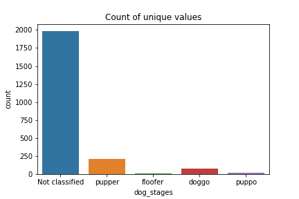

### Insight #3:

**Distribution of Retweet count**

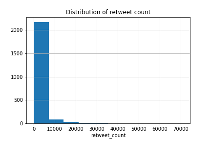

The boxplot below showes that for values above 5000,there are outliers

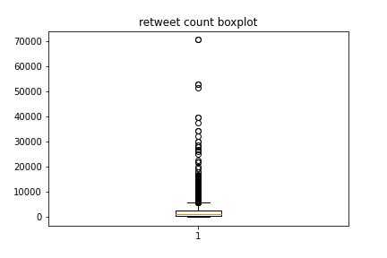

### Insight #4:

**Distribution of favorite count**

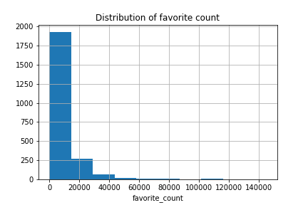

The box plot below showes that for like count above 20000,there are outliers

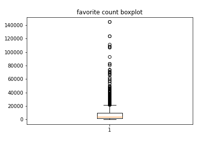

### Insight #4:

**Relationship between retweet count and like count**

There is a positive correlation between retweet count and like count with a correlation coefficient of 0.93 implying that as the favorite count increases,the retweet count tends to increase

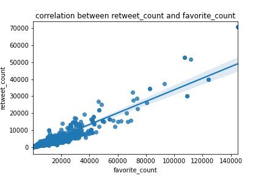